# Group Lasso with Sparse Data

MEMadsen

May 2, 2018

# 1 Document Updated last:

```r
st.time.0 <- Sys.time()
st.time.0
```

```
## [1] "2018-05-08 00:25:03 EDT"
```

```r
# Import Data data(Sonar) write.csv(Sonar, file = paste(DATA.DIR,
# 'sonar.csv', sep='') )
Sonar <- read.csv(file = paste(DATA.DIR, "sonar.csv", sep = "/"))
Sonar <- select(Sonar, -X)

# reomve rows with missing values Sonar_completeCase =
# Sonar[complete.cases(Sonar),] Sonar =
# Sonar[sample(nrow(Sonar)),]

# Assign Predictors and Response
y = Sonar$Class
X = Sonar[, -61]
```

# 2 Exploratory Data Analysis

## 2.1 Initial Visualization

Without knowing anything about the data, my first 3 tasks are almost always:

- Are there missing values, and what is the missing data profile?
- How does the categorical frequency for each discrete variable look like?
- What is the distribution of each continuous variable?

The plot of missing data is not displayed because there is no missing data.

### 2.1.1 Categorical Frequency

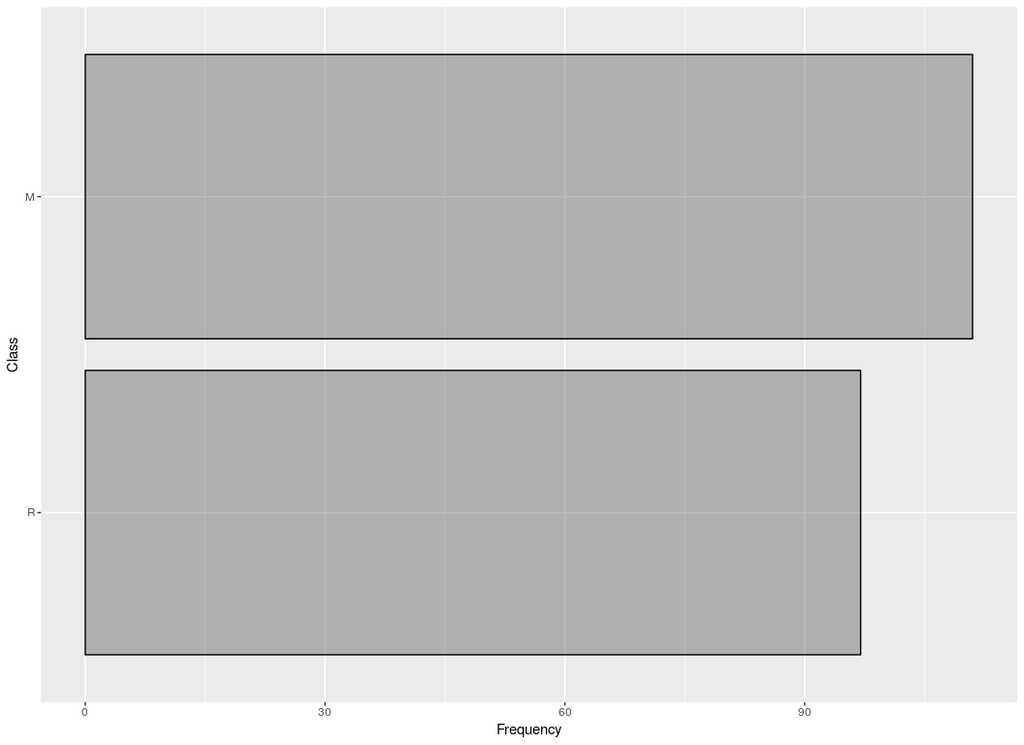

### 2.1.2 Continuous Distribution

Boxplots by Class label. Check for obviously different distribution of x-variables, by each class of Y.

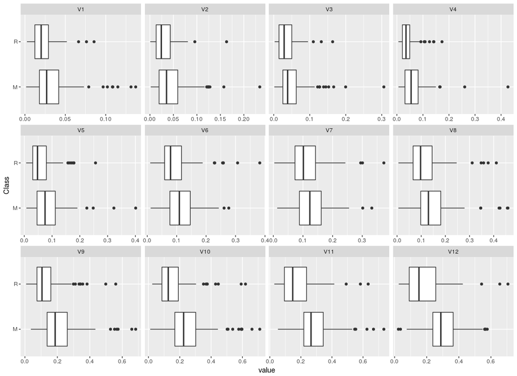

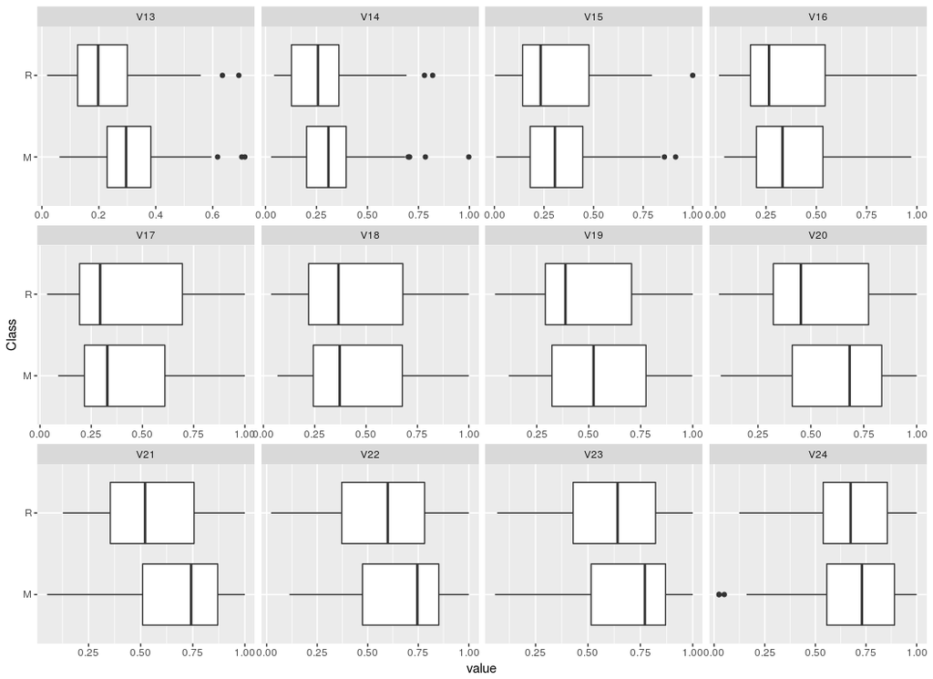

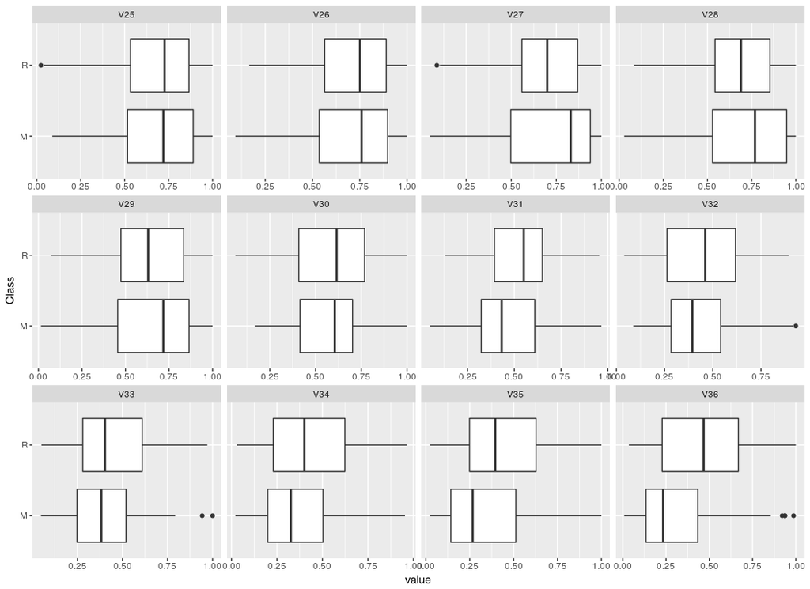

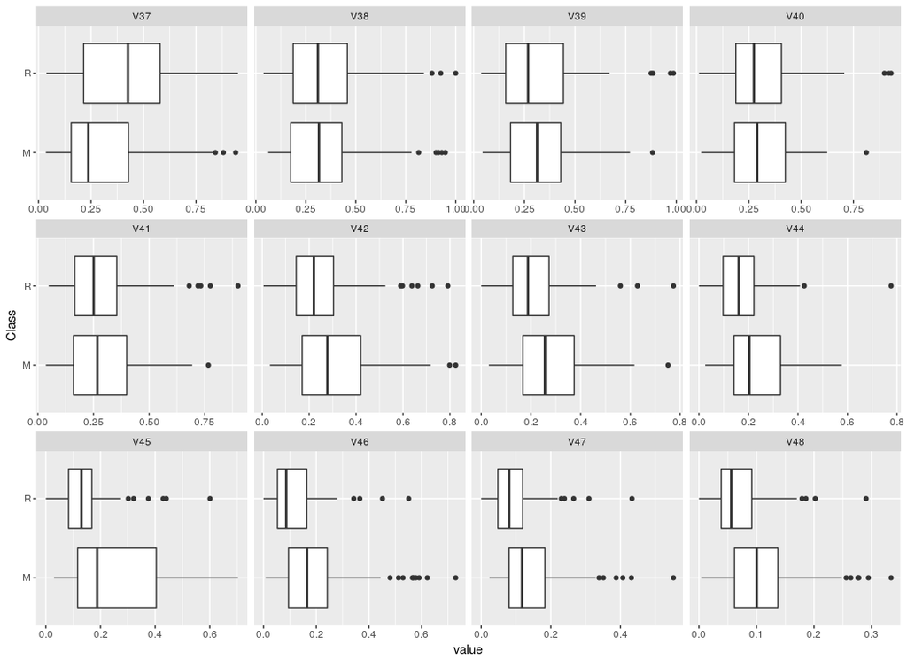

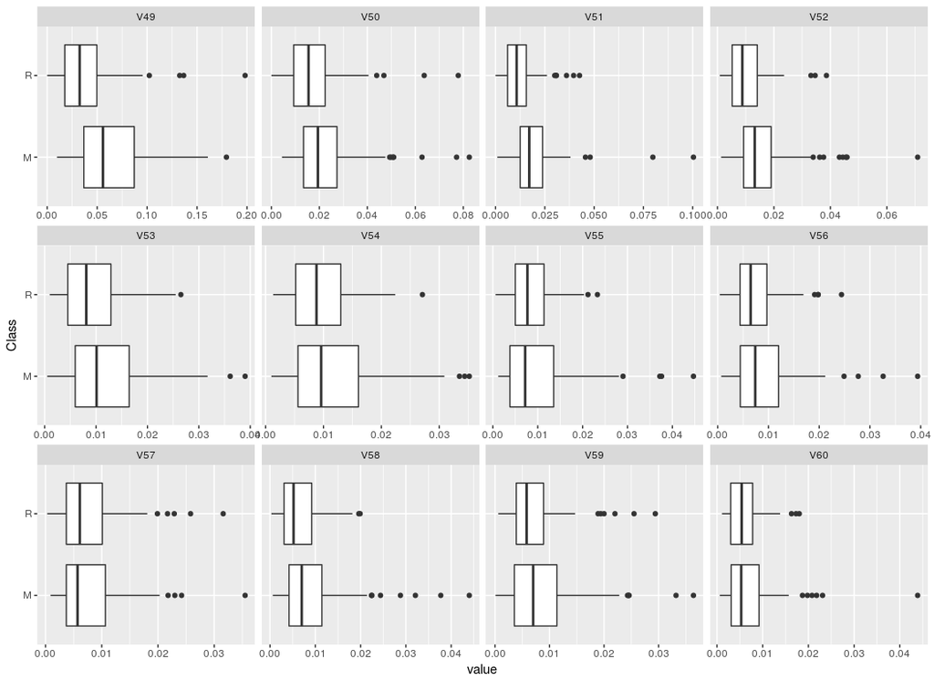

## 2.2 Data Overview

[output not shown]

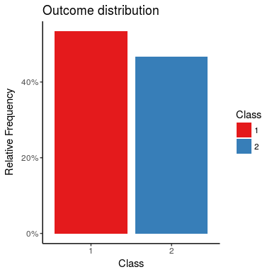

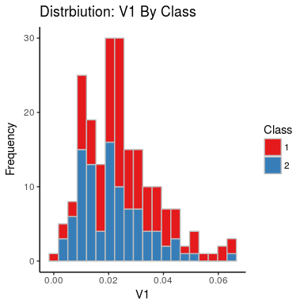

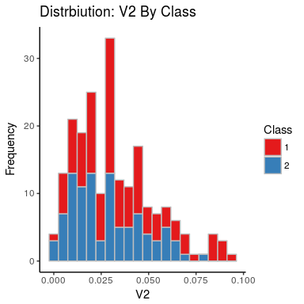

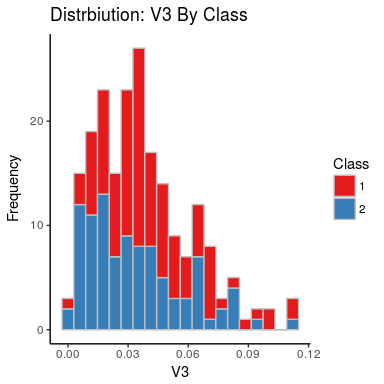

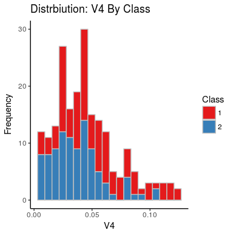

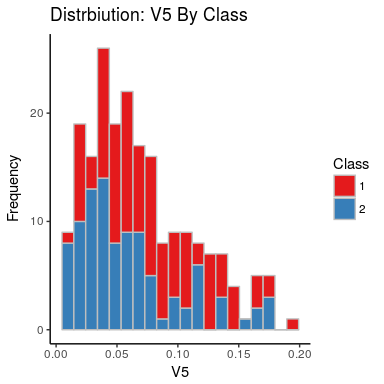

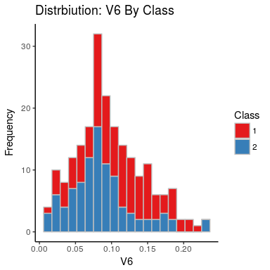

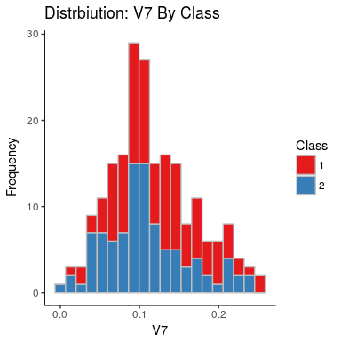

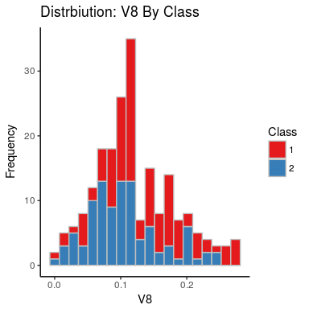

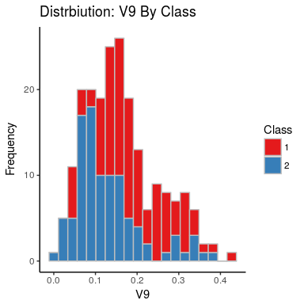

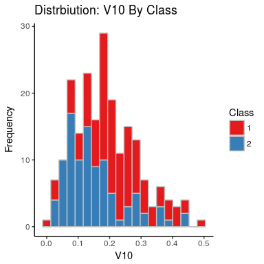

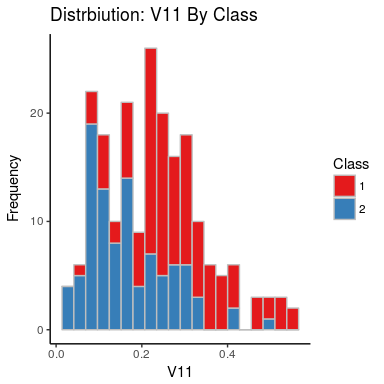

[50 more figures not shown]

## 2.3 Bivariate Freqploy

There is significant overlap from the Rock/Mine signal on many of the predictor variables. It appears to be challenging to find strong predictors from a large portion of the variables.

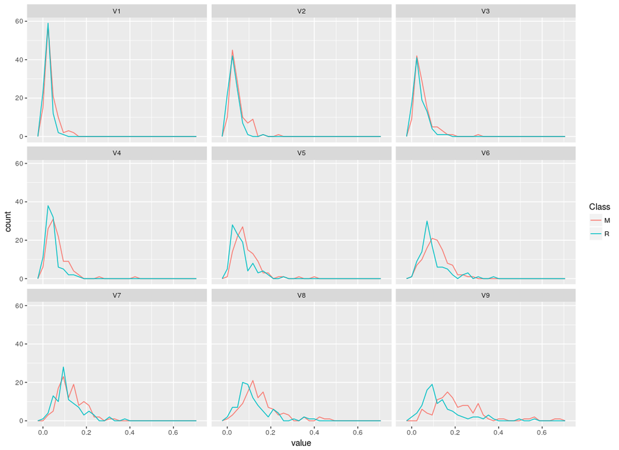

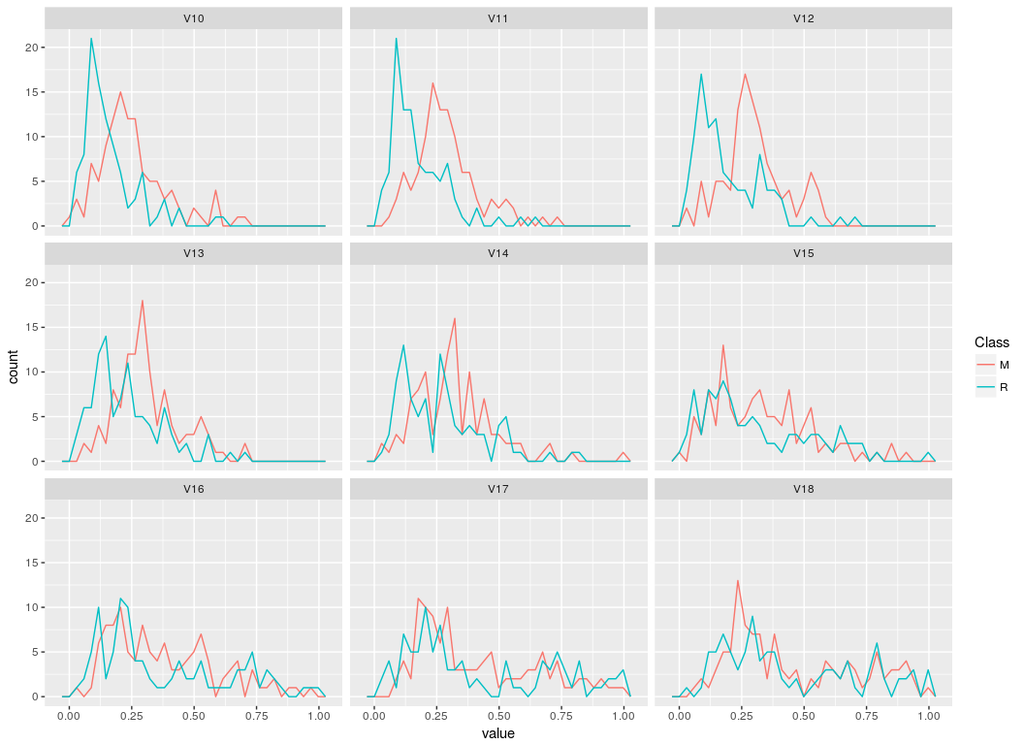

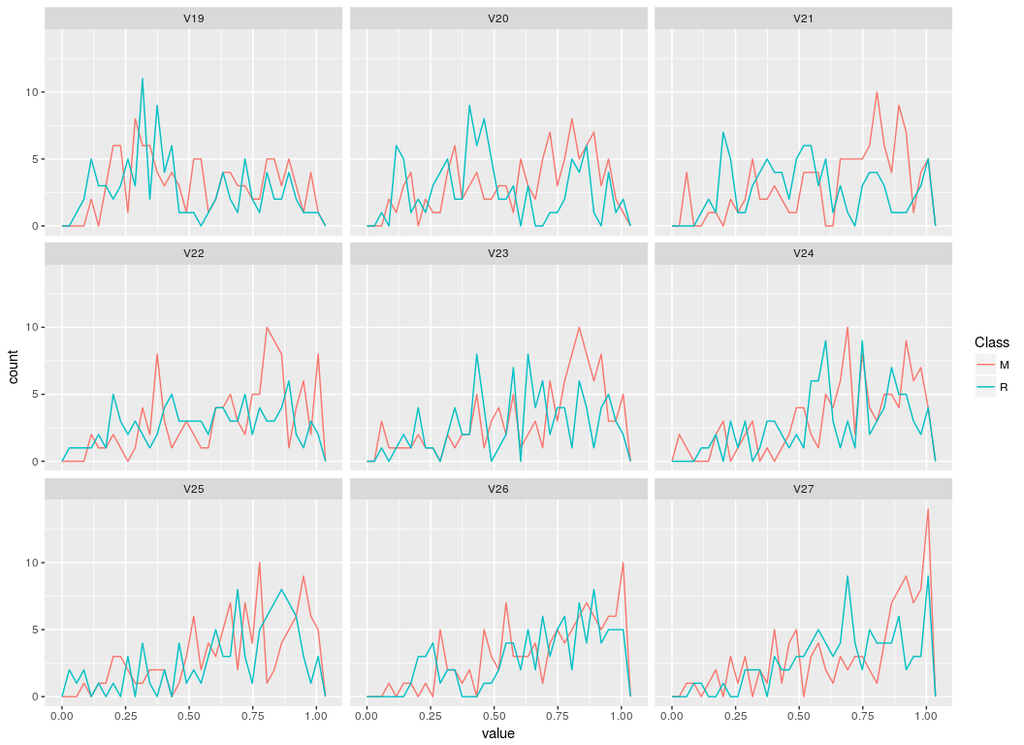

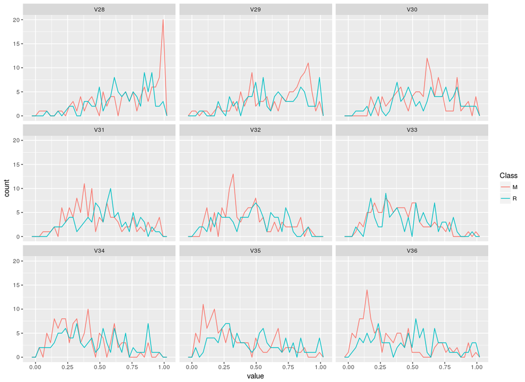

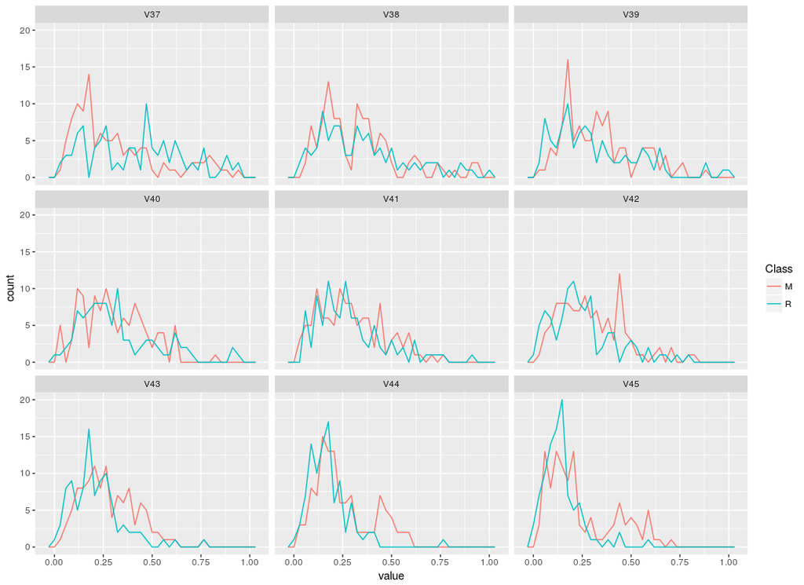

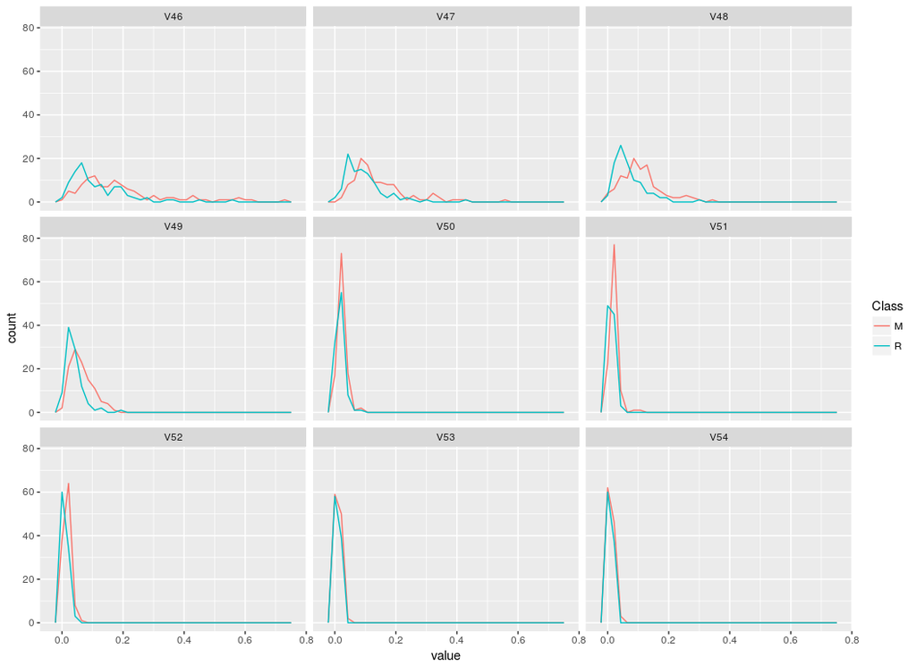

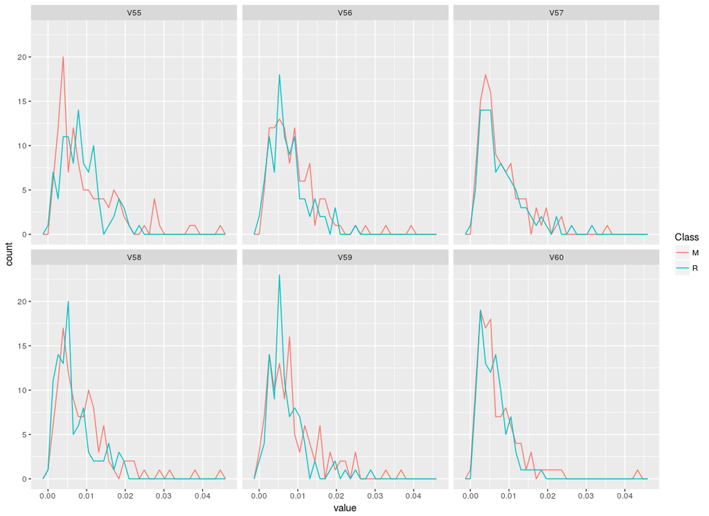

### 2.3.1 Maximal Information Coefficient

A new statistic called the “Maximal Information Coefficient” (MIC) is able to describe the correlation between paired variables regardless of linear or nonlinear relationship.

### 2.3.2 Correlation

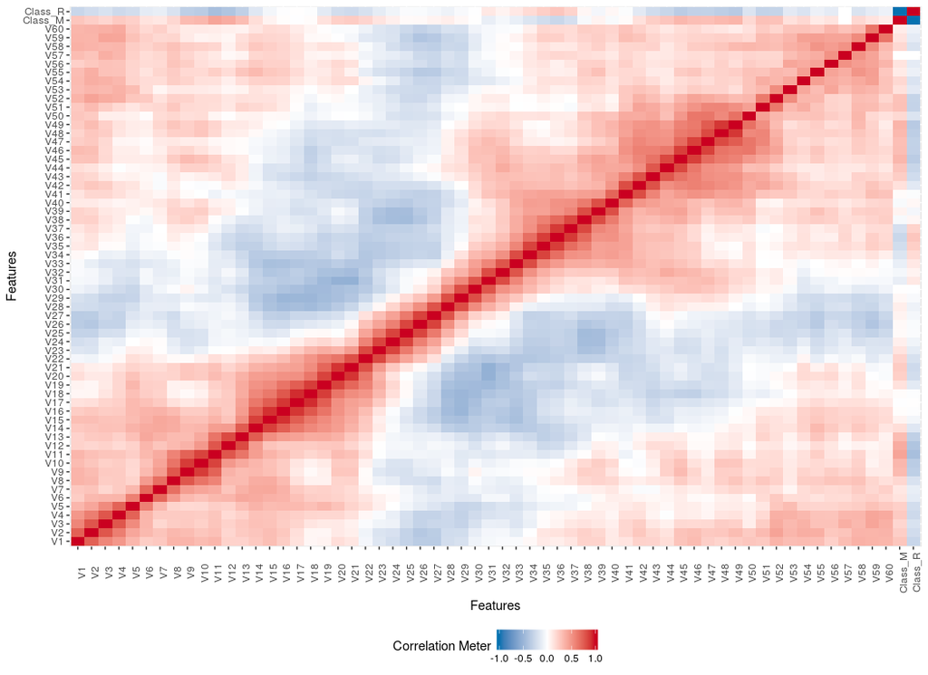

### 2.3.3 Hierarchial Clustering

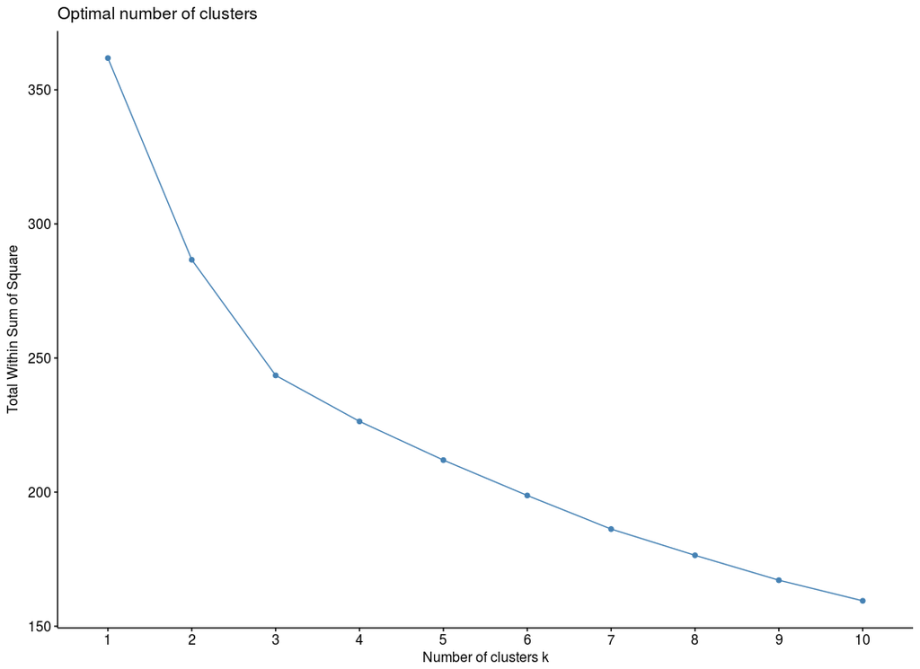

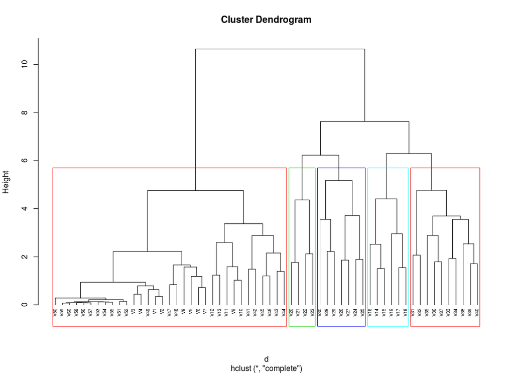

# 3 Machine Learning

The machine learning package H2O is leveraged using the R interface.

## 3.1 Embed machine learning file into main file.

```r
## Read R Script source('deep_learn_h2o.R') source(file =
## paste(CODE.DIR, 'deep_learn_h2o.R', sep='/') )
```

## 3.2 Child doc: Spin

The main file `grp_lasso.Rmd` imports a R script(s) and embeds into the main doc. The outputs can be messy or buggy but there are many benefits to logically distributing long files.

This child file `deep_learn_h20_roxy.R` uses roxygen formatting on a raw R file.

```r
# spin_child('/media/disc/Megasync/R/regularization/group_lasso/code/spinner_test.R')
{
    {
        knitr::spin_child("/media/disc/Megasync/R/regularization/group_lasso/code/deep_learn_h20_roxy.R")
    }
}
```

## 3.3 LIBRARIES for running h2o

```r
# Download packages that H2O depends on.
pkgs <- c("pROC", "RCurl", "jsonlite")
for (pkg in pkgs) {
    if (!(pkg %in% rownames(installed.packages()))) {
        install.packages(pkg)
    }
}
# Load libs
pkg.load <- c("AppliedPredictiveModeling", "bitops", "caret", "dplyr",
    "ggbiplot", "h2o", "mlbench", "pROC", "RCurl", "rjson", "ROCR",
    "statmod", "tools")
sapply(pkg.load, require, character.only = TRUE)
```

## 3.4 Helper File for DeepLearning Model

```r
source("/media/disc/Megasync/R/regularization/group_lasso/code/helper_h2o.R")
```

## 3.5 MAKE RESULTS REPEATABLE

```r
seed = 0
set.seed(seed)
```

INITIALIZE H2O ————————————————————–

```r
h2o <- h2o.init(nthreads = -1, max_mem_size = "14g")
```

[output not shown]

LOAD SONAR DATA AND CREATE TRAINING AND TEST SETS —————————

Load data into an H2O data frame

```r
# sonar.hex =
# h2o.importFile('/media/disc/Megasync/R/regularization/group_lasso/data/sonar_dl.csv')
sonar.hex <- h2o.importFile(path = pathToData, destination_frame = "sonar.hex")
# Convert the H2O data frame into an R data frame for later use.
sonar.df = as.data.frame(sonar.hex)
# sonar.df <- select(sonar.df, -C1)
```

Create the feature vectors by dropping the classifications

```r
classVariableIndex = 61
sonar.features = sonar.df[, -classVariableIndex]
# Rename the classification varible to something meaningful
names(sonar.df)[classVariableIndex] = "Class"
```

Use H2O to create the traning and test data sets from the original data. Use 80% of the data for training and 20% for testing. Pass in the seed value to make the results repeatable.

```r
sonar.split = h2o.splitFrame(data = sonar.hex, ratios = 0.8, seed = seed)
# Create named varaibles for the traning and test data
sonar.train = sonar.split[[1]]
sonar.test = sonar.split[[2]]
# Create R data frames from the H2O data frames
sonar.train.df = as.data.frame(sonar.train)
names(sonar.train.df)[classVariableIndex] = "Class"
sonar.test.df = as.data.frame(sonar.test)
names(sonar.test.df)[classVariableIndex] = "Class"
```

## 3.6 TRELLIS PLOT

```r
transparentTheme(trans = 0.5)
featurePlot <- featurePlot(x = sonar.features, y = sonar.df$Class,
    plot = "pairs", pscales = FALSE, cex = 0.05, auto.key = list(columns = 2))
```

## 3.7 PRINCIPAL COMPONENT ANALYSIS OF DATA SET

Generally, anything with more than 10 features is considered high dimensional data. Text mining and genomic microarrays have thousands of dimensions and they are the go-to examples of high dimensional data. —

```r
# Use principal components to reduce the dimensionality of the features.
sonar.princomp = prcomp(sonar.features, #x.vars,
                        center = TRUE,
                        scale = TRUE,
                        #tol=.3, #rank. = 15,
                        retx = TRUE)
sonar.princomp.7 = prcomp(sonar.features, #x.vars,
                        center = TRUE,
                        scale = TRUE,
                        tol=.4,
                        retx = TRUE)
```

Plot the first three principal components. Together, the first three principle components accounts for almost 50% of the variance in the data! That means they are very rich in information. After the PCA transformation, The original data set contains 60 features. If we think of the first three principal components as features, then 3 features can account for 50% of the information in the original data set. That means the the first three principle components consume only 3/60, or just 5% of the space as the original data, but contains almost half the signal. The upshot is that PCA is a kind of lossy data compression!

## 3.8 PCA Cumulative Variance

Look at cumulative proportion of the variance explained by the principle components:

```r
summary(sonar.princomp.7)
```

```
## Importance of first k=7 (out of 60) components:
##                           PC1    PC2    PC3     PC4     PC5     PC6
## Standard deviation     3.4940 3.3672 2.2649 1.84595 1.73328 1.56173
## Proportion of Variance 0.2035 0.1890 0.0855 0.05679 0.05007 0.04065
## Cumulative Proportion  0.2035 0.3924 0.4779 0.53473 0.58480 0.62545
##                            PC7
## Standard deviation     1.40264
## Proportion of Variance 0.03279
## Cumulative Proportion  0.65824
```

```r
# PCA TRELLIS PLOT ++++++++++++++++++++
transparentTheme(trans = 0.3)
numberOfPrincipalComponentsToPlot = 3
```

Plotting the principle components shows us that the rocks and mines have a lot of overlap. The more overlaps, the harder it will be for the machine learning algorithm to distinguish the difference between rocks and mines. However, it is easy to see the two classes do not overlap entirely; there is definitely some signal for the algorithm to lock onto.

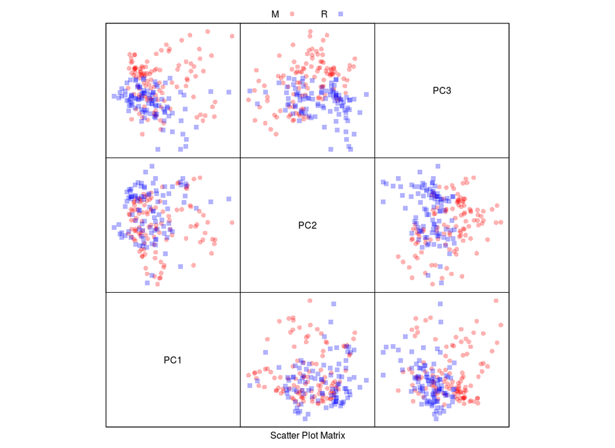

```r
featurePlot(x = sonar.princomp$x[, 1:numberOfPrincipalComponentsToPlot],
    y = sonar.df$Class, plot = "pairs", pscales = FALSE, auto.key = list(columns = 2))
```

### 3.8.1 PLOT FIRST AND SECOND PRINCIPLE COMPONENTS ———————————-

Use a special libary to plot the first principle component against the second principle component. Draw a ellipses around the observations. Observations inside the ellipse are less than 1 std dev away from mean.

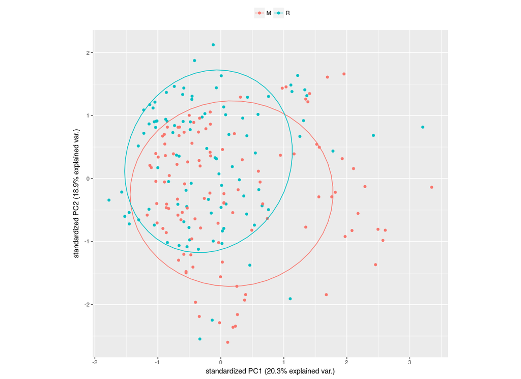

```r
g <- ggbiplot(
  sonar.princomp,
  groups = sonar.df$Class,
  var.axes = FALSE,
  #
  ellipse = TRUE
  )
g <- g + scale_color_discrete(name = '')
g <- g + theme(legend.direction = 'horizontal',
               legend.position = 'top')
print(g)
```

## 3.9 MACHINE LEARNING EXPERIMENTS ————————————————

### 3.9.1 Decision Tree

Let’s see how a decision tree does. Having a baseline to compare accuracy is useful.

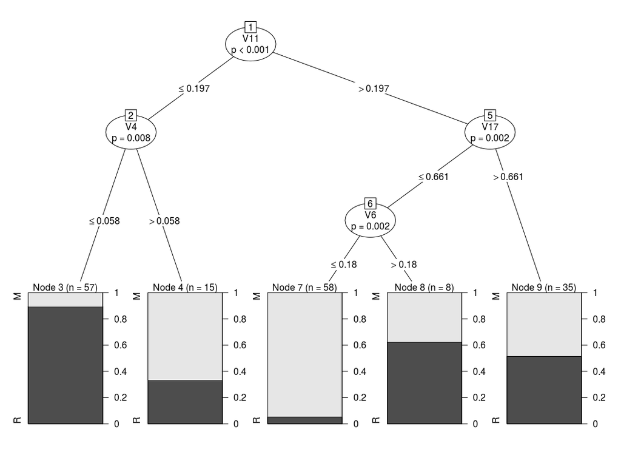

```r
decisionTree = train(Class ~ ., sonar.train.df, method = "ctree")
# Visually inspect the tree.
plot(decisionTree$finalModel)
```

Evaluate the decision tree performance

```r
decisionTree.predictions = predict(decisionTree, sonar.test.df[, -classVariableIndex])
confusionMatrix(decisionTree.predictions, sonar.test.df$Class)
```

```
## Confusion Matrix and Statistics
##
##           Reference
## Prediction  M  R
##          M 15  2
##          R  5 13
##
##                Accuracy : 0.8
##                  95% CI : (0.6306, 0.9156)
##     No Information Rate : 0.5714
##     P-Value [Acc > NIR] : 0.003999
##
##                   Kappa : 0.6016
##  Mcnemar's Test P-Value : 0.449692
##
##             Sensitivity : 0.7500
##             Specificity : 0.8667
##          Pos Pred Value : 0.8824
##          Neg Pred Value : 0.7222
##              Prevalence : 0.5714
##          Detection Rate : 0.4286
##    Detection Prevalence : 0.4857
##       Balanced Accuracy : 0.8083
##
##        'Positive' Class : M
##
```

## 3.10 AUC results

The area-under-curve (AUC) results look good.

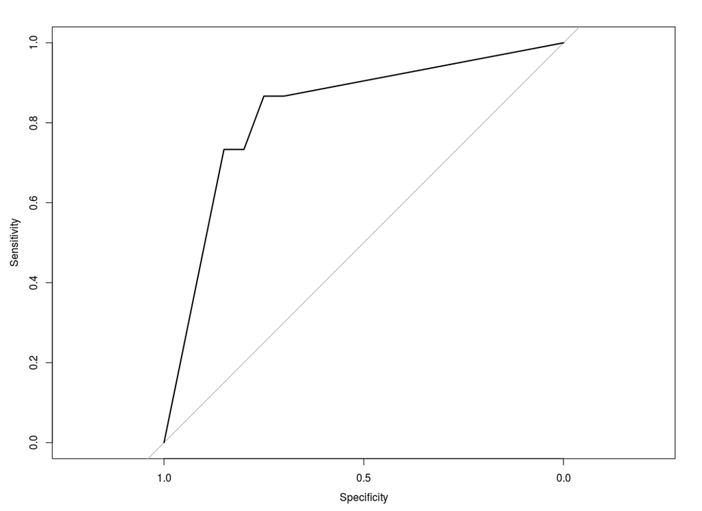

```r
decisionTree.predictions.probabilities = predict(decisionTree, sonar.test.df[,
    -classVariableIndex], type = "prob")
decisionTree.roc = roc(sonar.test.df$Class, decisionTree.predictions.probabilities$M)
# Area under the curve: 0.8433
plot(decisionTree.roc)
```

Review ROC plots. Explain it in terms of classifying rocks vs mines. The more tolerant you are of “slop” (false positives), the more you can be sure you aren’t missing any true positives. The more willing you are to accept the computer misclassifying, the less likely you are to miss-classify a mine.

PS: ROC curve technical background requires some understanding. I’ve been meaning to read these articles about it: http://blogs.sas.com/content/iml/2011/07/29/computing-an-roc-curve-from-basic-principles.html http://www.dataschool.io/roc-curves-and-auc-explained/